```python
%%capture
%pip install -r requirements.txt
```

```python
from IPython.display import display
import numpy as np
import matplotlib.pyplot as plt

from math import ceil, sqrt
from pathlib import Path

import torch
import torch.nn as nn
import torch.optim as optim
from torch.utils.data import DataLoader
import torchvision
import torchvision.datasets as datasets
import torchvision.transforms as T
from torchvision.transforms import InterpolationMode
import torchvision.transforms.functional as F

from train import train_model, TrainingResult, visualize_training_results

%matplotlib inline

device = torch.device('cuda' if torch.cuda.is_available() else 'xpu' if torch.xpu.is_available() else 'cpu')
display(f"Using device: {device}")

seed = 14_02_2003
np.random.seed(seed)

torch.random.manual_seed(seed)
if torch.cuda.is_available():
    torch.cuda.random.manual_seed_all(seed)
```

```
'Using device: cpu'
```

# Класификација модела авиона са фотографија коришћењем неуронских мрежа

У овом пројекту развијамо систем за класификацију различитих модела авиона на основу фотографија. Примјењене су савремене технике рачунарског вида и дубоког учења како би се развила три модела, са циљем поређења њихових перформанси и проналажења најбољег приступа. Прво је имплементирана конволутивна неуронска мрежа од нуле, а затим примјењено трансфер учење са Resnet18 и EfficientNetV2s моделима као основе.

## Скуп података

Користимо *FGVC-Aircraft* скуп података. Од 120 варијанти авиона класификоваћемо следеће:

```python
variants = {
    "F/A-18",
    "F-16A/B",
    "Eurofighter Typhoon",
    "Hawk T1",
    "Tornado",
    "C-130",
    "An-12",
    "Il-76",
    "737-800",
    "747-200"
};
```

Преузимамо скуп података уз помоћ `download_fgvcaircraft.py` скрипте. Она ће скинути комплетан скуп података у привремени фолдер, копирати фотографије жељених варијанти у `data_dir`, а затим обрисати оригинални скуп података. При копирању фотографије се организују у под-директоријуме за тренинг, валидацију и тест, а затим и по класама.

*Препорука је да се команди испод дода аргумент путање гдје је FGVC-Aircraft већ или гдје да буде сачуван, како би избјегли поновно преузимање. (`-r "./data"`)*

```python
_variants_arg = ' '.join(map('"{}"'.format, variants))

data_dir = Path('./data')
%run download_fgvcaircraft.py -r $data_dir -o $data_dir -a variant -s train val test --classes $_variants_arg
```

```
[['737-800', '747-200', 'An-12', 'C-130', 'Eurofighter Typhoon'],
 ['F-16AB', 'FA-18', 'Hawk T1', 'Il-76', 'Tornado']]
```

[figure not shown]

```
Dataset ImageFolder
    Number of datapoints: 334
    Root location: data\train
    StandardTransform
Transform: Compose(
               Resize(size=[224, 224], interpolation=bilinear, max_size=None, antialias=True)
               ToTensor()
           )
```

```python
showcase_dataset = datasets.ImageFolder(data_dir/"train", transform=T.Compose([T.Resize([224, 224]), T.ToTensor()]))

classes = showcase_dataset.classes
num_classes = len(classes)

labels, indices = np.unique([label for _, label in showcase_dataset.samples], return_index=True)
images = torch.stack([showcase_dataset[i][0] for i in indices])

nrow = ceil(sqrt(len(images) * 2))
grid = torchvision.utils.make_grid(images, nrow=nrow).numpy().transpose(1, 2, 0)

display(
    np.reshape(classes, [-1, nrow], copy=True).tolist(),
    T.ToPILImage(mode='RGB')(grid),
    showcase_dataset
)
```

### Претпроцесирање

Претпроцесирање у *PyTorch-у* се обавља коришћењем трансформација. Трансформација прима податке на улазу, обрађује их, и даје друге податке на излазу. За визуелну класификацију постоје предефинисане трансформације (у модулу `torchvision.transforms`), које су корисне за обраду фотографија. Ове трансформације се могу комбиновати тако да излаз једне буде улаз у другу, формирајући пајплајн (pipeline).

Да би се максимизовала ефикасност фотографије обрађујемо користећи `Image` објекте, које непосредно прије прослеђивања неуронској мрежи конвертујемо у тензор.

```python
IMG_SHAPE = 240, 240

class RemoveCopyright:
    def __call__(self, img):
        match type(img):
            case torch.Tensor:
                _, h, w = img.shape
            case _:
                w, h = img.size

        return F.crop(img, top=0, left=0, height=(h - 20), width=w) # 20px copyright bottom banner

    def __repr__(self) -> str:
        return f"{self.__class__.__name__}()"

remove_copyright = RemoveCopyright()
resize = T.Resize(IMG_SHAPE)
to_tensor = T.ToTensor()
to_pil = T.ToPILImage(mode='RGB') # inverse from to_tensor (used for displaying images)
# TODO: Perform standardization with mean and std
```

*Због јаснијег приказа пајплајна трансформација не користимо уграђену `torchvision.transforms.Lambda` трансформацију него дефинишемо нову.*

При обучавању конволутивне неуронске мреже од нуле, параметре нормализације — као што је величина слике, средња вриједност (mean) и стандардна девијација (std) — можемо слободно прилагодити како би дали најбоље резултате за наш модел и податке.

Међутим, када користимо **трансфер учење** (transfer learning) и ослањамо се на унапред обучене моделе (у нањем случају *ResNet18* и *EfficientNetV2s*), онда морамо поштовати исте нормализационе параметре који су коришћени током њихове иницијалне обуке — у супротном мрежа неће исправно „разумјети” нове улазе.

Поред трансформација намјењених нормализацији улазних података, пошто не располажемо великим скупом података, користићемо и насумичне трансформације **тренинг** података — поступак познат као аугментација (augmentation). Циљ ових трансформација јесте да „вјештачки” повећамо скуп података, увођењем нпр. насумичних ротација или промјена контраста. Пошто моделу показујемо исту фотографију (са диска) више пута, овим трансформацијама добијамо варијације исте слике, што помаже бољој генерализацији модела.

#### КНМ од нуле

У блоку испод дефинишемо комплетан пајплајне претпроцесирања за конволутивну неуронску мрежу од нуле.

```python
transforms_train = T.Compose([
    remove_copyright,
    resize,
    T.RandomHorizontalFlip(),
    T.RandomRotation(degrees=7),
    T.ColorJitter(brightness=2e-1, contrast=2e-1),
    to_tensor
])

transforms_eval = T.Compose([
    remove_copyright,
    resize,
    to_tensor
]);
```

Како се само тренинг подаци аугментују, дефинишемо посебне трансформације за тренинг, а посебне за валидацију и тестирање.

#### Трансфер учење - ResNet18

Библиотека `torchvision` нуди разне унапред трениране моделе познатих архитектура. Један од њих је *ResNet18*, обучен над ImageNet v1 1k (1000 класа) скупом података. Дефинишемо пајплајнe претпроцесирања за трансфер учење са *ResNet18* моделом.

```python
from torchvision.models import ResNet18_Weights, resnet18

resnet_weights = ResNet18_Weights.IMAGENET1K_V1
display(resnet_weights.transforms())
```

```
ImageClassification(
    crop_size=[224]
    resize_size=[256]
    mean=[0.485, 0.456, 0.406]
    std=[0.229, 0.224, 0.225]
    interpolation=InterpolationMode.BILINEAR
)
```

Енумерацијама формата `<architecture name>_Weights`, бирамо скуп података над којим је архитектура тренирана. Такође од конкретне вриједности енумерације можемо сазнати коришћене параметре нормализације.

```python
resnet_transforms_train = T.Compose([
    remove_copyright,
    T.Resize(256, interpolation=InterpolationMode.BILINEAR),
    T.CenterCrop(224),
    T.RandomHorizontalFlip(),
    T.RandomRotation(degrees=7),
    T.ColorJitter(brightness=2e-1, contrast=2e-1),
    to_tensor,
    T.Normalize(
        mean=[0.485, 0.456, 0.406],
        std=[0.229, 0.224, 0.225]
    )
])

resnet_transforms_eval = T.Compose([
    remove_copyright,
    T.Resize(256, interpolation=InterpolationMode.BILINEAR),
    T.CenterCrop(224),
    to_tensor,
    T.Normalize(
        mean=[0.485, 0.456, 0.406],
        std=[0.229, 0.224, 0.225]
    )
]);
```

#### Трансфер учење - EfficientNetV2s

Иако `torchvision` нуди EfficientNetV2s архитектуру, не нуди опцију унапред трениране над ImageNet v1 21k (21,000 класа) — зато користимо библиотеку `timm`. Инспекцијом конфигурације нормализационих параметара за модел, креирамо претпроцесирајућe пајплајнe.

```python
import timm
from timm.data.config import resolve_data_config

enet_model_name = "tf_efficientnetv2_s.in21k"
enet_config = resolve_data_config({}, model=enet_model_name)
display(enet_config)
```

```
{'input_size': (3, 224, 224),
 'interpolation': 'bicubic',
 'mean': (0.485, 0.456, 0.406),
 'std': (0.229, 0.224, 0.225),
 'crop_pct': 0.875,
 'crop_mode': 'center'}
```

```python
enet_transforms_train = T.Compose([
    remove_copyright,
    T.Resize(int(224 // 0.875), interpolation=InterpolationMode.BICUBIC),
    T.CenterCrop(224),
    T.RandomHorizontalFlip(),
    T.RandomRotation(degrees=7),
    T.ColorJitter(brightness=2e-1, contrast=2e-1),
    to_tensor,
    T.Normalize(
        mean=[0.485, 0.456, 0.406],
        std=[0.229, 0.224, 0.225]
    )
])

enet_transforms_eval = T.Compose([
    remove_copyright,
    T.Resize(int(224 // 0.875), interpolation=InterpolationMode.BICUBIC),
    T.CenterCrop(224),
    to_tensor,
    T.Normalize(
        mean=[0.485, 0.456, 0.406],
        std=[0.229, 0.224, 0.225]
    )
]);
```

## Тренирање модела

Процес тренирања извршава се у више **епоха** (`EPOCHS`) — једна епоха обухвата један пролазак кроз комплетан тренинг скуп података. Током тренирања пратимо перформансе модела на **валидационом скупу**. Ако се метрика модела не побољша током фише узастопних епоха (`PATIENCE`), прекидамо тренинг да би спријечили претренирање (overfitting).

*Имплементација тренинг петље са визуелизацијом се налази у `train.py` модулу.*

```python
EPOCHS = 50
BATCH_SIZE = 2**5 # 32
PATIENCE = 8
```

### КНМ од нуле

Имплементирана конволутивна неуронска мрежа се састоји из више слојева:

- **4 конволутивна блока** — намјена препознавање карактеристика (feature)
- **Global Average Pooling** — сманјује димензије
- **Потпуно повезан (fully connected) класификатор** са `Dropоut`-ом

Ова структура омогућава мрежи да постепено учи све сложеније карактеристике, уз контролу *overfitting-a*.

```python
class AircraftCNNClassifier(nn.Module):

    def __init__(self, num_classes: int):
        super(AircraftCNNClassifier, self).__init__()
        self.features = nn.Sequential(
            nn.Conv2d(3, 32, kernel_size=3, padding=1),
            nn.ReLU(inplace=True),
            nn.BatchNorm2d(32),
            nn.MaxPool2d(kernel_size=2, stride=2),

            nn.Conv2d(32, 64, kernel_size=3, padding=1),
            nn.ReLU(inplace=True),
            nn.BatchNorm2d(64),
            nn.MaxPool2d(kernel_size=2, stride=2),

            nn.Conv2d(64, 128, kernel_size=3, padding=1),
            nn.ReLU(inplace=True),
            nn.BatchNorm2d(128),
            nn.MaxPool2d(kernel_size=2, stride=2),

            nn.Conv2d(128, 256, kernel_size=3, padding=1),
            nn.ReLU(inplace=True),
            nn.BatchNorm2d(256),
            nn.MaxPool2d(kernel_size=2, stride=2),
        )

        self.avgpool = nn.AdaptiveAvgPool2d(1)
        self.classifier = nn.Sequential(
            nn.Dropout(p=0.5),
            nn.Linear(256, 128),
            nn.ReLU(inplace=True),
            nn.Dropout(p=0.3),
            nn.Linear(128, num_classes)
        )

    def forward(self, x):
        x = self.features(x)
        x = self.avgpool(x)
        x = torch.flatten(x, 1)
        x = self.classifier(x)
        return x
```

```python
dataset = {
    'train': datasets.ImageFolder(data_dir/"train", transform=transforms_train),
    'val': datasets.ImageFolder(data_dir/"val", transform=transforms_eval),
    'test': datasets.ImageFolder(data_dir/"test", transform=transforms_eval)
}

model = AircraftCNNClassifier(num_classes).to(device)
```

```python
results = train_model(
    model,
    train_loader=DataLoader(dataset['train'], BATCH_SIZE, shuffle=True),
    val_loader=DataLoader(dataset['val'], BATCH_SIZE),
    patience=PATIENCE,
    num_epochs=EPOCHS,
    num_classes=num_classes,
    optimizer=optim.SGD,
    device=device,
    lr=1e-4,
    out_file="cnn_best_model.pth",
)
```

#### Анализа резултата

Training Results

Training finished at epoch 7.

- **Train loss:** 2.337

- **Train accuracy:** 0.089

- **Validation accuracy:** 0.106

- **Validation F1 score:** 0.055

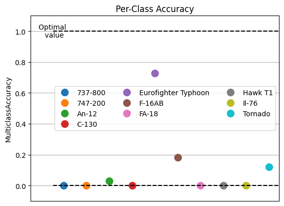

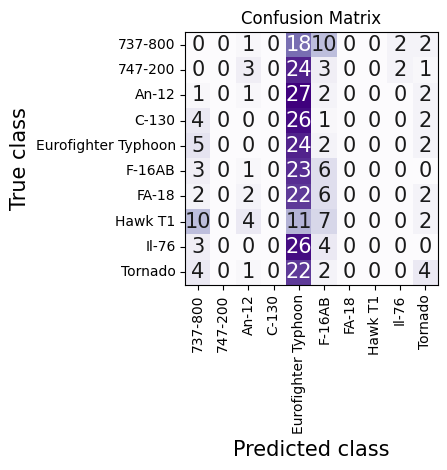

```python
visualize_training_results(results, labels=classes)
```

### Трансфер учење - Resnet18

```python
resnet_dataset = {
    'train': datasets.ImageFolder(data_dir/"train", transform=resnet_transforms_train),
    'val': datasets.ImageFolder(data_dir/"val", transform=resnet_transforms_eval),
    'test': datasets.ImageFolder(data_dir/"test", transform=resnet_transforms_eval)
}

resnet_model = resnet18(weights=resnet_weights)

for param in resnet_model.parameters():
    param.requires_grad = False

resnet_model.fc = nn.Linear(resnet_model.fc.in_features, num_classes)

for param in resnet_model.fc.parameters():
    param.requires_grad = True

resnet_model = resnet_model.to(device);
```

```python
resnet_results = train_model(
    resnet_model,
    train_loader=DataLoader(resnet_dataset['train'], BATCH_SIZE, shuffle=True),
    val_loader=DataLoader(resnet_dataset['val'], BATCH_SIZE),
    patience=PATIENCE,
    num_epochs=EPOCHS,
    num_classes=num_classes,
    optimizer=optim.Adam,
    device=device,
    lr=1e-3,
    out_file="resnet_best_model.pth",
)
```

#### Анализа резултата

Training Results

Training finished at epoch 34.

- **Train loss:** 0.463

- **Train accuracy:** 0.904

- **Validation accuracy:** 0.720

- **Validation F1 score:** 0.719

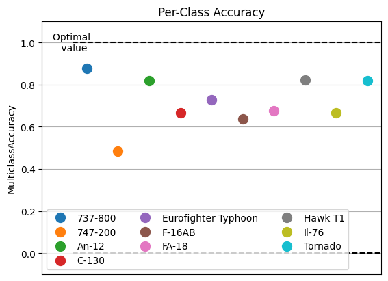

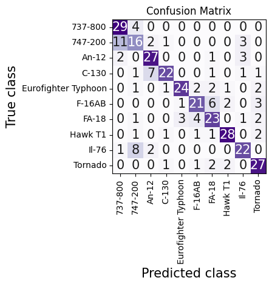

```python
visualize_training_results(resnet_results, labels=classes)
```

### Трансфер учење - EfficientNetV2s

```python
enet_dataset = {
    'train': datasets.ImageFolder(data_dir/"train", transform=enet_transforms_train),
    'val': datasets.ImageFolder(data_dir/"val", transform=enet_transforms_eval),
    'test': datasets.ImageFolder(data_dir/"test", transform=enet_transforms_eval)
}

enet_model = timm.create_model(enet_model_name, pretrained=True)

for param in enet_model.parameters():
    param.requires_grad = False

enet_model.reset_classifier(num_classes=num_classes) # type: ignore # pyright: ignore
#enet_model.classifier = nn.Linear(enet_model.classifier.in_features, len(classes)) # type: ignore # pyright: ignore

for param in enet_model.get_classifier().parameters(): # type: ignore # pyright: ignore
    param.requires_grad = True

enet_model = enet_model.to(device);
```

```python
enet_results = train_model(
    enet_model,
    train_loader=DataLoader(enet_dataset['train'], BATCH_SIZE, shuffle=True),
    val_loader=DataLoader(enet_dataset['val'], BATCH_SIZE),
    patience=PATIENCE,
    num_epochs=EPOCHS,
    num_classes=num_classes,
    optimizer=optim.Adam,
    lr=1e-3,
    out_file='enet_best_model.pth',
)
```

#### Анализа резултата

Training Results

[figure not shown]

[figure not shown]

```python
visualize_training_results(resnet_results, labels=classes)
```

### Евалуација модела

```python
def eval_model(model, test_loader):
    from torchmetrics.classification import Accuracy
    model =  model.to(device)
    model.eval()

    accuracy = Accuracy(task='multiclass', num_classes=num_classes)

    with torch.no_grad():
        for images, labels in test_loader:
            images, labels = images.to(device), labels.to(device)

            preds = model(images)
            preds = torch.argmax(preds, dim=1)
            accuracy.update(preds, labels)

    return accuracy.compute().item()
```

```python
model = AircraftCNNClassifier(num_classes)
model.load_state_dict(torch.load('cnn_best_model.pth'))

resnet_model = resnet18()
resnet_model.fc = nn.Linear(resnet_model.fc.in_features, num_classes)
resnet_model.load_state_dict(torch.load('resnet_best_model.pth'))

enet_model = timm.create_model(enet_model_name, pretrained=False, num_classes=num_classes)
enet_model.load_state_dict(torch.load('enet_best_model.pth'))


accuracy = eval_model(model, DataLoader(dataset['test'], BATCH_SIZE))
resnet_accuracy = eval_model(resnet_model, DataLoader(resnet_dataset['test'], BATCH_SIZE))
enet_accuracy = eval_model(enet_model, DataLoader(enet_dataset['test'], BATCH_SIZE))

display(
    f"CNN from scratch accuracy:  {accuracy:.3f}",
    f"Resnet18 accuracy: {resnet_accuracy:.3f}",
    f"EfficientNetV2s accuracy: {enet_accuracy:.3f}"
)
```

```
'CNN from scratch accuracy:  0.084'
```

```
'Resnet18 accuracy: 0.740'
```

```
'EfficientNetV2s accuracy: 0.719'
```